# ReneWind — Wind Turbine Generator Failure Prediction (Full Code)

### 5.7 Model 4 — Dropout regularization

**Technique:** **Dropout** (0.3) after hidden layers with 2-layer architecture.

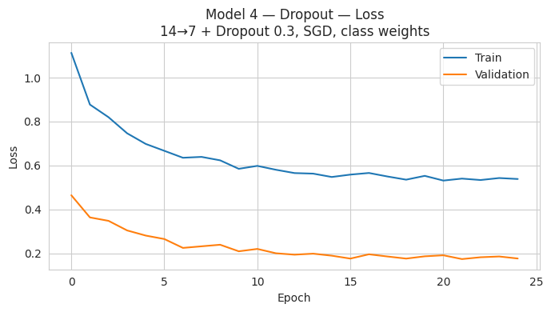

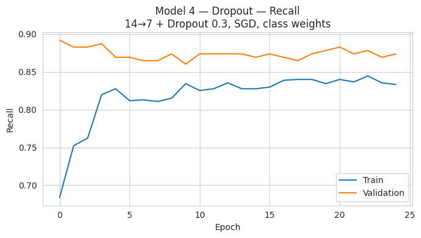

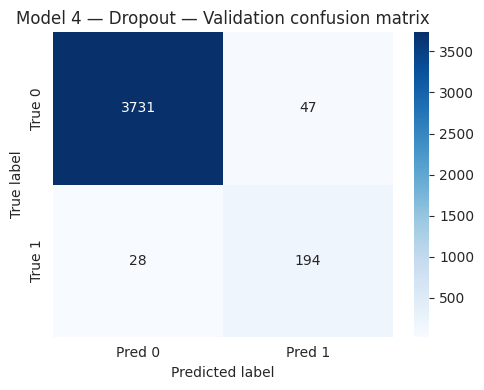

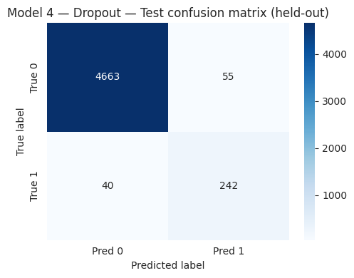

```
Training time: 19.6s
Validation maintenance cost: $4,265,000 | Cost efficiency: 0.7808
```

|  | Accuracy | Recall | Precision | F1 | Maintenance_Cost | Cost_Efficiency |
| --- | --- | --- | --- | --- | --- | --- |
| Model 4 — Dropout | 0.981375 | 0.885135 | 0.800407 | 0.840642 | 16850000 | 0.790504 |

|  | Accuracy | Recall | Precision | F1 | Maintenance_Cost | Cost_Efficiency |
| --- | --- | --- | --- | --- | --- | --- |
| Model 4 — Dropout | 0.98125 | 0.873874 | 0.804979 | 0.838013 | 4265000 | 0.780774 |

```python
model_4 = Sequential([
    Input(shape=(X_train.shape[1],)),
    Dense(14, activation='relu'),
    Dropout(0.3),
    Dense(7, activation='relu'),
    Dropout(0.3),
    Dense(1, activation='sigmoid'),
])
model_4.compile(loss='binary_crossentropy', optimizer=SGD(), metrics=['Recall'])
model_4, _ = train_and_evaluate(
    'Model 4 — Dropout',
    model_4,
    config_note='14→7 + Dropout 0.3, SGD, class weights',
)
```

**Observation (Model 4):** **Dropout** regularization. Prefer this model if validation **maintenance cost** falls while recall stays acceptable (fewer costly FN replacements).

### 5.8 Model 5 — Without class weights

**Technique:** remove **class weights** to measure impact on minority (failure) class.

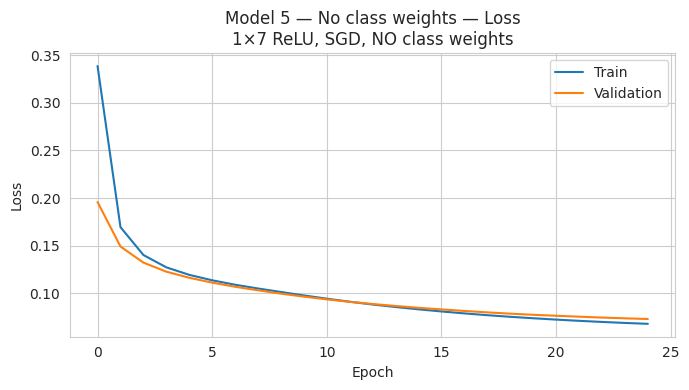

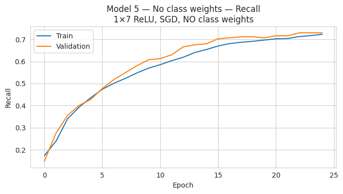

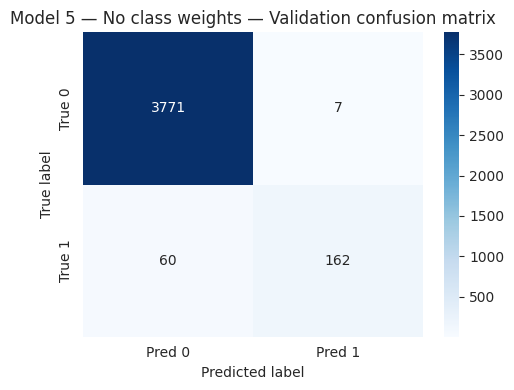

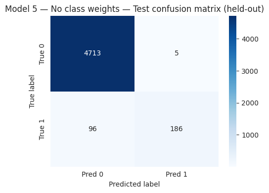

```
Training time: 18.9s
Validation maintenance cost: $4,865,000 | Cost efficiency: 0.6845
```

|  | Accuracy | Recall | Precision | F1 | Maintenance_Cost | Cost_Efficiency |
| --- | --- | --- | --- | --- | --- | --- |
| Model 5 — No class weights | 0.983375 | 0.718468 | 0.975535 | 0.827497 | 19650000 | 0.677863 |

|  | Accuracy | Recall | Precision | F1 | Maintenance_Cost | Cost_Efficiency |
| --- | --- | --- | --- | --- | --- | --- |
| Model 5 — No class weights | 0.98325 | 0.72973 | 0.95858 | 0.828645 | 4865000 | 0.684481 |

```python
model_5 = Sequential([
    Input(shape=(X_train.shape[1],)),
    Dense(7, activation='relu'),
    Dense(1, activation='sigmoid'),
])
model_5.compile(loss='binary_crossentropy', optimizer=SGD(), metrics=['Recall'])
model_5, _ = train_and_evaluate(
    'Model 5 — No class weights',
    model_5,
    use_class_weight=False,
    config_note='1×7 ReLU, SGD, NO class weights',
)
```

**Observation (Model 5):** No **class weights** — expect higher validation **maintenance cost** (more FN → replacements). Confirms weighted training is required for dollar-optimal maintenance.

### 5.9 Model 6 — Combined best practices (Adam + depth + dropout + class weights)

**Technique:** combine **Adam**, **extra hidden layer**, **dropout**, and **class weights**.

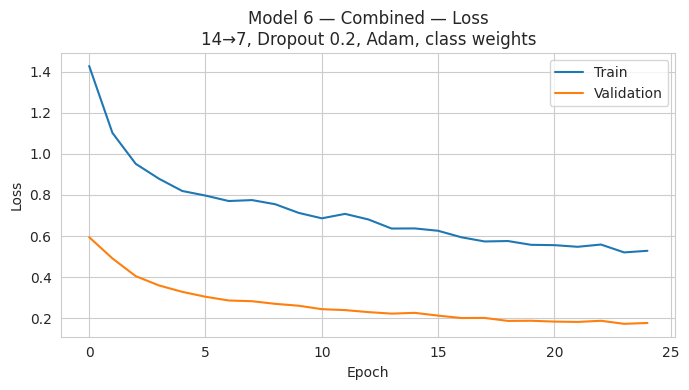

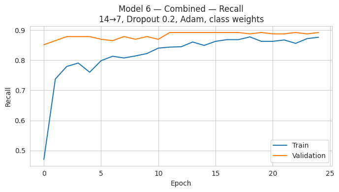

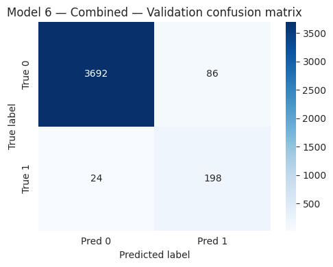

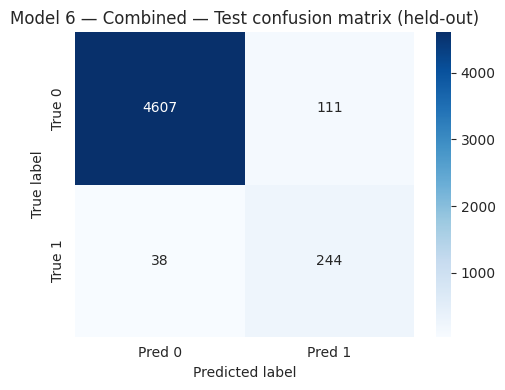

```
Training time: 21.2s
Validation maintenance cost: $4,360,000 | Cost efficiency: 0.7638
```

|  | Accuracy | Recall | Precision | F1 | Maintenance_Cost | Cost_Efficiency |
| --- | --- | --- | --- | --- | --- | --- |
| Model 6 — Combined | 0.969938 | 0.907658 | 0.66888 | 0.770186 | 17365000 | 0.76706 |

|  | Accuracy | Recall | Precision | F1 | Maintenance_Cost | Cost_Efficiency |
| --- | --- | --- | --- | --- | --- | --- |
| Model 6 — Combined | 0.9725 | 0.891892 | 0.697183 | 0.782609 | 4360000 | 0.763761 |

```python
model_6 = Sequential([
    Input(shape=(X_train.shape[1],)),
    Dense(14, activation='relu'),
    Dropout(0.2),
    Dense(7, activation='relu'),
    Dropout(0.2),
    Dense(1, activation='sigmoid'),
])
model_6.compile(loss='binary_crossentropy', optimizer=Adam(learning_rate=0.0005), metrics=['Recall'])
model_6, _ = train_and_evaluate(
    'Model 6 — Combined',
    model_6,
    config_note='14→7, Dropout 0.2, Adam, class weights',
)
```

**Observation (Model 6):** Combined **Adam + dropout + depth**. Strong candidate if it achieves the best validation **cost efficiency** among tunable architectures.

### 5.10 Model 7 — Adam + three hidden layers + dropout

**Technique:** deeper **Adam** network with dropout (sixth+ architecture variant).

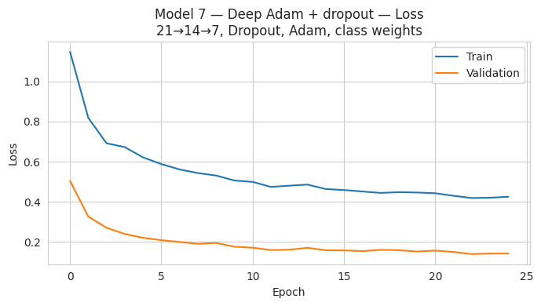

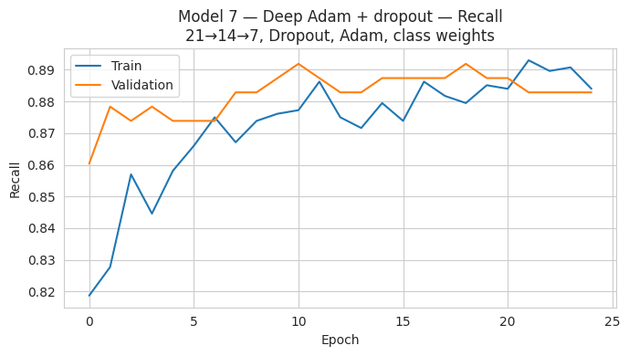

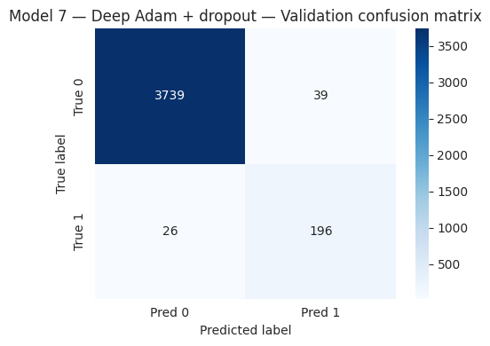

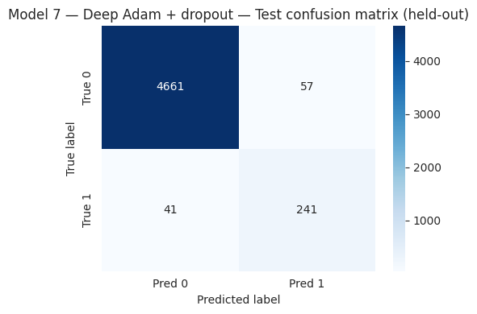

```
Training time: 20.8s
Validation maintenance cost: $4,175,000 | Cost efficiency: 0.7976
```

|  | Accuracy | Recall | Precision | F1 | Maintenance_Cost | Cost_Efficiency |
| --- | --- | --- | --- | --- | --- | --- |
| Model 7 — Deep Adam + dropout | 0.986187 | 0.902027 | 0.856684 | 0.878771 | 16165000 | 0.824002 |

|  | Accuracy | Recall | Precision | F1 | Maintenance_Cost | Cost_Efficiency |
| --- | --- | --- | --- | --- | --- | --- |
| Model 7 — Deep Adam + dropout | 0.98375 | 0.882883 | 0.834043 | 0.857768 | 4175000 | 0.797605 |

```python
model_7 = Sequential([
    Input(shape=(X_train.shape[1],)),
    Dense(21, activation='relu'),
    Dropout(0.25),
    Dense(14, activation='relu'),
    Dropout(0.25),
    Dense(7, activation='relu'),
    Dense(1, activation='sigmoid'),
])
model_7.compile(loss='binary_crossentropy', optimizer=Adam(learning_rate=0.0005), metrics=['Recall'])
model_7, _ = train_and_evaluate(
    'Model 7 — Deep Adam + dropout',
    model_7,
    config_note='21→14→7, Dropout, Adam, class weights',
)
```

**Observation (Model 7):** Deepest **Adam + dropout** stack. Select only if validation **maintenance cost** is lowest or efficiency is highest vs. simpler models (avoid overfit that increases FN/FP dollars).

## 6 — Model Comparison and Final Selection (dollar-based)

```
=== Training metrics ===
```

|  | Accuracy | Recall | Precision | F1 | Maintenance_Cost | Cost_Efficiency |
| --- | --- | --- | --- | --- | --- | --- |
| Model 0 — Baseline | 0.958812 | 0.898649 | 0.583760 | 0.707761 | 18415000 | 0.723323 |
| Model 1 — 2 hidden layers | 0.985187 | 0.909910 | 0.837306 | 0.872099 | 16105000 | 0.827072 |
| Model 2 — 3 hidden layers | 0.985750 | 0.918919 | 0.839506 | 0.877419 | 15900000 | 0.837736 |
| Model 3 — Adam optimizer | 0.961938 | 0.902027 | 0.605442 | 0.724559 | 18105000 | 0.735708 |
| Model 4 — Dropout | 0.981375 | 0.885135 | 0.800407 | 0.840642 | 16850000 | 0.790504 |
| Model 5 — No class weights | 0.983375 | 0.718468 | 0.975535 | 0.827497 | 19650000 | 0.677863 |
| Model 6 — Combined | 0.969938 | 0.907658 | 0.668880 | 0.770186 | 17365000 | 0.767060 |
| Model 7 — Deep Adam + dropout | 0.986187 | 0.902027 | 0.856684 | 0.878771 | 16165000 | 0.824002 |

```
=== Validation metrics — sorted by cost efficiency (primary KPI) ===
```

|  | Accuracy | Recall | Precision | F1 | Maintenance_Cost | Cost_Efficiency |
| --- | --- | --- | --- | --- | --- | --- |
| Model 7 — Deep Adam + dropout | 0.98375 | 0.882883 | 0.834043 | 0.857768 | 4175000 | 0.797605 |
| Model 2 — 3 hidden layers | 0.98350 | 0.873874 | 0.836207 | 0.854626 | 4220000 | 0.789100 |
| Model 4 — Dropout | 0.98125 | 0.873874 | 0.804979 | 0.838013 | 4265000 | 0.780774 |
| Model 1 — 2 hidden layers | 0.98200 | 0.869369 | 0.817797 | 0.842795 | 4270000 | 0.779859 |
| Model 6 — Combined | 0.97250 | 0.891892 | 0.697183 | 0.782609 | 4360000 | 0.763761 |
| Model 3 — Adam optimizer | 0.96475 | 0.887387 | 0.629393 | 0.736449 | 4535000 | 0.734289 |
| Model 0 — Baseline | 0.96125 | 0.887387 | 0.602446 | 0.717668 | 4605000 | 0.723127 |
| Model 5 — No class weights | 0.98325 | 0.729730 | 0.958580 | 0.828645 | 4865000 | 0.684481 |

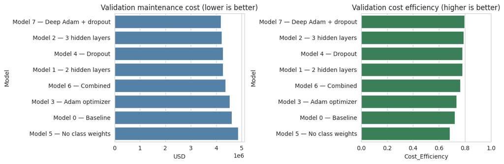

```python
train_df = pd.concat(results_train.values(), axis=0)
val_df = pd.concat(results_val.values(), axis=0)
test_df = pd.concat(results_test.values(), axis=0)

print('=== Training metrics ===')
display(train_df)

print('=== Validation metrics — sorted by cost efficiency (primary KPI) ===')
val_sorted = val_df.sort_values(
    ['Cost_Efficiency', 'Maintenance_Cost'],
    ascending=[False, True],
)
display(val_sorted)

# Visual: validation maintenance cost by model
plot_df = val_sorted.reset_index().rename(columns={'index': 'Model'})
fig, axes = plt.subplots(1, 2, figsize=(12, 4))
sns.barplot(data=plot_df, x='Maintenance_Cost', y='Model', ax=axes[0], color='steelblue')
axes[0].set_title('Validation maintenance cost (lower is better)')
axes[0].set_xlabel('USD')
sns.barplot(data=plot_df, x='Cost_Efficiency', y='Model', ax=axes[1], color='seagreen')
axes[1].set_title('Validation cost efficiency (higher is better)')
axes[1].set_xlim(0, 1)
plt.tight_layout()
plt.show()
```

```python
# --- Step 1: Pick architecture by validation dollars (not recall) ---
best_row = val_df.sort_values(
    ['Cost_Efficiency', 'Maintenance_Cost', 'Recall'],
    ascending=[False, True, False],
).iloc[0]
best_name = best_row.name
print('Selected architecture (validation cost efficiency):', best_name)
display(best_row.to_frame().T)

model_lookup = {
    'Model 0 — Baseline': model_0,
    'Model 1 — 2 hidden layers': model_1,
    'Model 2 — 3 hidden layers': model_2,
    'Model 3 — Adam optimizer': model_3,
    'Model 4 — Dropout': model_4,
    'Model 5 — No class weights': model_5,
    'Model 6 — Combined': model_6,
    'Model 7 — Deep Adam + dropout': model_7,
}
best_model = model_lookup[best_name]
```

```
Selected architecture (validation cost efficiency): Model 7 — Deep Adam + dropout
```

|  | Accuracy | Recall | Precision | F1 | Maintenance_Cost | Cost_Efficiency |
| --- | --- | --- | --- | --- | --- | --- |
| Model 7 — Deep Adam + dropout | 0.98375 | 0.882883 | 0.834043 | 0.857768 | 4175000.0 | 0.797605 |

### 6.1 Threshold tuning on validation (maintenance cost)

Default probability cutoff is 0.5. For O&M, we tune the cutoff on the **validation set only** so predicted maintenance **dollars** are minimized (equivalently, cost efficiency is maximized).

|  | threshold | Maintenance_Cost | Cost_Efficiency | Recall | FN | FP | TP |
| --- | --- | --- | --- | --- | --- | --- | --- |
| 10 | 0.60 | 4090000 | 0.814181 | 0.882883 | 26 | 22 | 196 |
| 12 | 0.70 | 4090000 | 0.814181 | 0.878378 | 27 | 17 | 195 |
| 11 | 0.65 | 4100000 | 0.812195 | 0.878378 | 27 | 19 | 195 |
| 9 | 0.55 | 4115000 | 0.809235 | 0.882883 | 26 | 27 | 196 |
| 13 | 0.75 | 4115000 | 0.809235 | 0.869369 | 29 | 12 | 193 |
| 14 | 0.80 | 4120000 | 0.808252 | 0.864865 | 30 | 8 | 192 |
| 15 | 0.85 | 4160000 | 0.800481 | 0.855856 | 32 | 6 | 190 |
| 8 | 0.50 | 4175000 | 0.797605 | 0.882883 | 26 | 39 | 196 |
| 7 | 0.45 | 4225000 | 0.788166 | 0.882883 | 26 | 49 | 196 |
| 16 | 0.90 | 4230000 | 0.787234 | 0.842342 | 35 | 5 | 187 |

```
Optimal validation threshold: 0.6
Validation maintenance cost at best threshold: $4,090,000
Validation cost efficiency: 0.8142
```

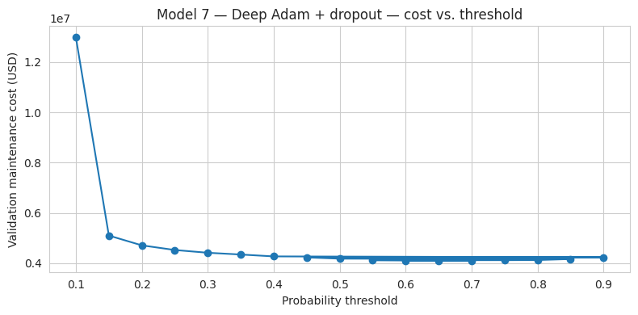

```python
threshold_grid = np.round(np.arange(0.10, 0.91, 0.05), 2)
threshold_rows = []

for t in threshold_grid:
    perf, cm = model_performance(best_model, X_val, y_val, threshold=float(t), label=f't={t}')
    threshold_rows.append({
        'threshold': t,
        'Maintenance_Cost': perf['Maintenance_Cost'].iloc[0],
        'Cost_Efficiency': perf['Cost_Efficiency'].iloc[0],
        'Recall': perf['Recall'].iloc[0],
        'FN': int(cm[1, 0]),
        'FP': int(cm[0, 1]),
        'TP': int(cm[1, 1]),
    })

threshold_df = pd.DataFrame(threshold_rows).sort_values(
    ['Cost_Efficiency', 'Maintenance_Cost'], ascending=[False, True]
)
display(threshold_df.head(10))

best_threshold_row = threshold_df.iloc[0]
BEST_THRESHOLD = float(best_threshold_row['threshold'])
print(f'Optimal validation threshold: {BEST_THRESHOLD}')
print(f"Validation maintenance cost at best threshold: ${int(best_threshold_row['Maintenance_Cost']):,}")
print(f"Validation cost efficiency: {best_threshold_row['Cost_Efficiency']:.4f}")

plt.figure(figsize=(8, 4))
plt.plot(threshold_df['threshold'], threshold_df['Maintenance_Cost'], marker='o')
plt.xlabel('Probability threshold')
plt.ylabel('Validation maintenance cost (USD)')
plt.title(f'{best_name} — cost vs. threshold')
plt.tight_layout()
plt.show()
```

```
=== Final validation performance (tuned threshold) ===
```

|  | Accuracy | Recall | Precision | F1 | Maintenance_Cost | Cost_Efficiency |
| --- | --- | --- | --- | --- | --- | --- |
| Model 7 — Deep Adam + dropout (val, tuned) | 0.988 | 0.882883 | 0.899083 | 0.890909 | 4090000 | 0.814181 |

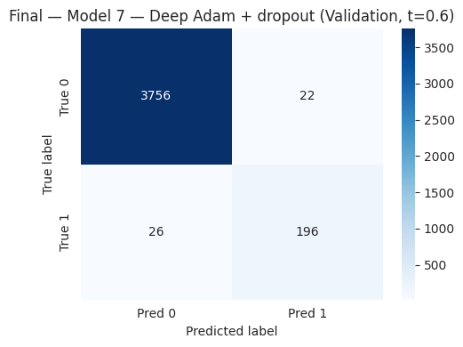

```
=== Final test performance (held-out; evaluate once) ===
```

|  | Accuracy | Recall | Precision | F1 | Maintenance_Cost | Cost_Efficiency |
| --- | --- | --- | --- | --- | --- | --- |
| Model 7 — Deep Adam + dropout (test) | 0.983 | 0.851064 | 0.848057 | 0.849558 | 5495000 | 0.769791 |

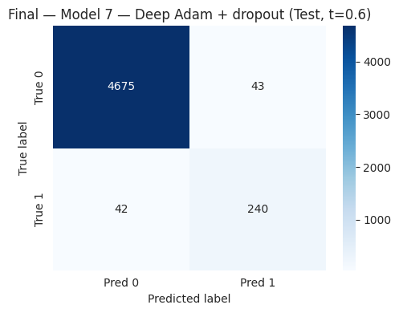

```
Test confusion counts — TP: 240 FN: 42 FP: 43 TN: 4675
Test maintenance cost: $5,495,000
Test cost efficiency: 0.7698
```

```python
# --- Step 2: One-time held-out test evaluation at dollar-optimal threshold ---
val_final_perf, val_final_cm = model_performance(
    best_model, X_val, y_val, threshold=BEST_THRESHOLD, label=best_name + ' (val, tuned)'
)
final_test_perf, final_cm = model_performance(
    best_model, X_test, y_test, threshold=BEST_THRESHOLD, label=best_name + ' (test)'
)

print('=== Final validation performance (tuned threshold) ===')
display(val_final_perf)
show_confusion(val_final_cm, f'Final — {best_name} (Validation, t={BEST_THRESHOLD})')

print('=== Final test performance (held-out; evaluate once) ===')
display(final_test_perf)
show_confusion(final_cm, f'Final — {best_name} (Test, t={BEST_THRESHOLD})')

tn, fp, fn, tp = final_cm.ravel()
print('Test confusion counts — TP:', tp, 'FN:', fn, 'FP:', fp, 'TN:', tn)
print('Test maintenance cost: $' + f"{int(final_test_perf['Maintenance_Cost'].iloc[0]):,}")
print('Test cost efficiency:', round(final_test_perf['Cost_Efficiency'].iloc[0], 4))
```

**Final model reasoning:**

1. **Architecture** — chosen by highest **validation cost efficiency**, then lowest **validation maintenance cost**, then recall as a tie-breaker.
2. **Threshold** — tuned on validation only to minimize maintenance dollars (same cost function as the business brief).
3. **Test set** — scored **once** at the tuned threshold; no test-set tuning (no leakage).

This aligns model selection with ReneWind's stated goal: **reduce O&M spend**, not optimize a surrogate metric in isolation.

## 7 — Actionable Insights and Business Recommendations

### Key takeaways

1. **Dollar-based selection:** The production model is the architecture with the best **validation cost efficiency**, with decision threshold tuned to minimize **validation maintenance cost** — directly aligned with the project objective.
2. **Class weights are economically necessary:** Removing weights (Model 5) increases FN-driven **replacement** spend; weighted training is required for cost-optimal predictions.
3. **Recall is a diagnostic, not the KPI:** High recall helps, but the right threshold balances **$40k replacements** vs. **$5k inspections**; report both recall and maintenance cost to operations.
4. **Depth, Adam, and dropout:** Architectures that improve **validation cost efficiency** (not just training recall) should be favored for deployment.

### Business recommendations

1. **Deploy with the tuned probability cutoff** — use the validation-derived threshold in SCADA alerting so dispatch triggers inspections/repairs when expected cost is minimized.
2. **Executive dashboard in dollars** — monthly TP/FN/FP counts translated to maintenance cost and cost efficiency vs. a "repair-only" baseline.
3. **Retrain quarterly** — refresh weights and **re-tune threshold** on recent validation folds; sensor drift changes both predictions and optimal cutoff.
4. **Pilot on high-correlation turbines** — prioritize sites where top EDA sensors are stable and failure labels are well-logged.

### Expected benefits

- Lower total generator O&M cost (fewer replacements, right-sized inspections)
- Planned repairs instead of emergency replacements
- Clear ROI narrative for ReneWind leadership (cost efficiency trending toward 1.0)

*End of notebook — export to HTML for submission.*